# Ebola Outbreak Simulation and Analysis

A Complete Epiverse-TRACE Workflow Demonstration

Author

Epiverse-TRACE Team

Published

February 11, 2026

## Executive Summary

This document demonstrates a complete outbreak analysis pipeline using the Epiverse-TRACE ecosystem. We simulate an Ebola outbreak, clean the data, estimate case fatality risk (CFR), and create publication-ready visualizations.

**Key Results**:

- Simulated outbreak with realistic epidemiological parameters
- Cleaned and validated line list data
- Estimated delay-corrected CFR with uncertainty
- Generated reproducible visualizations

## Setup

### Load Required Packages

We use several Epiverse-TRACE packages along with standard R tools for data manipulation and visualization.

```r
# Configure repositories
options(repos = c(
  epiverse = "https://epiverse-trace.r-universe.dev",
  CRAN = "https://cloud.r-project.org"
))

# Load packages
library(simulist)      # Outbreak simulation
library(cleanepi)      # Data cleaning
library(linelist)      # Line list tagging
library(cfr)           # Case fatality risk estimation
library(epiparameter)  # Epidemiological parameters
library(tidyverse)     # Data manipulation
library(here)          # Portable file paths
library(qs)            # Fast serialization
library(tracetheme)    # Epiverse visualization theme
library(knitr)         # Table formatting
library(gt)            # Publication-quality tables

# Source workflow functions
# Note: Quarto sets working directory to document location
source(here::here("..", "..", "R", "workflow_functions.R"))

# Set random seed for reproducibility
set.seed(42)

# Display session info
cat("R version:", R.version.string, "\n")
```

```
R version: R version 4.5.1 (2025-06-13)
```

```r
cat("Analysis date:", format(Sys.Date(), "%Y-%m-%d"), "\n")
```

```
Analysis date: 2026-02-11
```

### Create Output Directories

```r
# Ensure output directories exist
dir.create(here::here("data", "raw"), recursive = TRUE, showWarnings = FALSE)
dir.create(here::here("data", "processed"), recursive = TRUE, showWarnings = FALSE)
dir.create(here::here("outputs", "plots"), recursive = TRUE, showWarnings = FALSE)
dir.create(here::here("outputs", "tables"), recursive = TRUE, showWarnings = FALSE)
```

## Background

### Ebola Virus Disease

Ebola virus disease (EVD) is a severe, often fatal illness in humans caused by the Ebola virus. The 2014-2016 West African outbreak was the largest in history, with over 28,000 cases and 11,000 deaths.

**Key Epidemiological Characteristics**:

- **Transmission**: Direct contact with bodily fluids
- **R₀**: Typically 1.5-2.5 (basic reproduction number)
- **Incubation Period**: 2-21 days (mean ~10 days)
- **Case Fatality Ratio**: 25-90% depending on strain and care quality
- **Infectious Period**: ~6 days on average

### Objectives

This analysis demonstrates:

1. **Simulation**: Generate realistic outbreak data using branching processes
2. **Data Cleaning**: Standardize and validate epidemiological data
3. **Statistical Analysis**: Estimate CFR with delay correction
4. **Visualization**: Create publication-ready epidemic curves and CFR plots

## Methodology

### 1. Epidemiological Parameters

We define disease parameters based on literature values for Ebola virus disease.

```r
# Setup parameters using literature values
params <- setup_ebola_parameters()

# Display parameter summaries
cat("Parameters configured successfully:\n")
```

```
Parameters configured successfully:
```

```r
cat("  - Contact Distribution: Poisson (R₀ ≈ 2)\n")
```

```
  - Contact Distribution: Poisson (R₀ ≈ 2)
```

```r
cat("  - Infectious Period: Gamma (mean ≈ 6 days)\n")
```

```
  - Infectious Period: Gamma (mean ≈ 6 days)
```

```r
cat("  - Incubation Period: Gamma (mean ≈ 10 days)\n")
```

```
  - Incubation Period: Gamma (mean ≈ 10 days)
```

```r
cat("  - Onset to Hospitalization: Gamma (mean ≈ 4 days)\n")
```

```
  - Onset to Hospitalization: Gamma (mean ≈ 4 days)
```

```r
cat("  - Onset to Death: Gamma (mean ≈ 8 days)\n")
```

```
  - Onset to Death: Gamma (mean ≈ 8 days)
```

#### Parameter Justification

- **R₀ = 2**: Conservative estimate from West African outbreak data
- **Infectious period = 6 days**: Based on WHO clinical reports
- **Incubation period = 10 days**: Median from systematic reviews
- **Onset to death = 8 days**: From Barry et al. (2018) CFR correction

### 2. Outbreak Simulation

We simulate an Ebola outbreak using a stochastic branching process model implemented in the `simulist` package.

```r
# Simulate outbreak
outbreak <- simulate_ebola_outbreak(
  params = params,
  outbreak_size = c(100, 500),  # Min and max cases
  start_date = as.Date("2024-01-01"),
  seed = 42
)

# Display simulation summary
cat("\nSimulation Results:\n")
```

```
Simulation Results:
```

```r
cat("  Cases generated:", nrow(outbreak$linelist), "\n")
```

```
  Cases generated: 559
```

```r
cat("  Contacts recorded:", nrow(outbreak$contacts), "\n")
```

```
  Contacts recorded: 937
```

```r
cat("  Date range:",
    format(min(outbreak$linelist$date_onset), "%Y-%m-%d"), "to",
    format(max(outbreak$linelist$date_onset), "%Y-%m-%d"), "\n")
```

```
  Date range: 2024-01-01 to 2024-04-01
```

#### Data Structure

The simulation produces two data frames:

**Line List** - Individual case records:

```r
outbreak$linelist |>
  select(id, date_onset, age, sex, outcome, date_outcome) |>
  head(10) |>
  gt() |>
  tab_header(title = "Simulated Line List (First 10 Cases)")
```

Simulated Line List (First 10 Cases)

| id | date_onset | age | sex | outcome | date_outcome |
| --- | --- | --- | --- | --- | --- |
| 1 | 2024-01-01 | 86 | f | recovered | NA |
| 3 | 2024-01-06 | 4 | m | recovered | NA |
| 4 | 2024-01-07 | 86 | m | recovered | NA |
| 7 | 2024-01-09 | 37 | m | recovered | NA |
| 8 | 2024-01-08 | 15 | f | recovered | NA |
| 10 | 2024-01-15 | 40 | m | died | 2024-01-24 |
| 11 | 2024-01-17 | 70 | f | recovered | NA |
| 13 | 2024-01-17 | 81 | m | recovered | NA |
| 14 | 2024-01-08 | 73 | m | recovered | NA |
| 17 | 2024-01-18 | 21 | f | died | 2024-01-28 |

**Contact Data** - Transmission chains:

```r
outbreak$contacts |>
  head(10) |>
  gt() |>
  tab_header(title = "Contact Tracing Data (First 10 Contacts)")
```

Contact Tracing Data (First 10 Contacts)

| from | to | age | sex | date_first_contact | date_last_contact | was_case | status |
| --- | --- | --- | --- | --- | --- | --- | --- |
| Abbey Benton | Shihaab al-Shahin | 53 | m | 2023-12-29 | 2024-01-05 | FALSE | under_followup |
| Abbey Benton | Joshua Mikulak | 4 | m | 2023-12-26 | 2024-01-07 | TRUE | case |
| Abbey Benton | Carlos Zabala | 86 | m | 2023-12-30 | 2024-01-02 | TRUE | case |
| Joshua Mikulak | Austin Jackson | 63 | m | 2024-01-02 | 2024-01-11 | FALSE | under_followup |
| Joshua Mikulak | Tory Canada Jr | 7 | m | 2024-01-05 | 2024-01-08 | FALSE | under_followup |
| Joshua Mikulak | Rene Barahona Medina | 37 | m | 2024-01-05 | 2024-01-08 | TRUE | case |
| Joshua Mikulak | Cinead Lopez | 15 | f | 2024-01-04 | 2024-01-09 | TRUE | case |
| Carlos Zabala | Cheno Thomas | 5 | m | 2024-01-06 | 2024-01-13 | FALSE | under_followup |
| Carlos Zabala | Brandon Vanderpool | 40 | m | 2024-01-06 | 2024-01-07 | TRUE | case |
| Rene Barahona Medina | Alexus Nimmons | 70 | f | 2024-01-02 | 2024-01-11 | TRUE | case |

### 3. Data Cleaning and Validation

Raw outbreak data often contains inconsistencies, missing values, and formatting issues. We use `cleanepi` and `linelist` packages to standardize and validate the data.

```r
# Clean and tag data
tagged_linelist <- clean_outbreak_data(outbreak$linelist)

# Show validation results
cat("\nData Quality Checks:\n")
```

```
Data Quality Checks:
```

```r
cat("  Total records:", nrow(tagged_linelist), "\n")
```

```
  Total records: 559
```

```r
cat("  Complete date_onset:", sum(!is.na(tagged_linelist$date_onset)), "\n")
```

```
  Complete date_onset: 559
```

```r
cat("  Complete outcome:", sum(!is.na(tagged_linelist$outcome)), "\n")
```

```
  Complete outcome: 559
```

```r
cat("  Deaths:", sum(tagged_linelist$outcome == "died", na.rm = TRUE), "\n")
```

```
  Deaths: 85
```

```r
cat("  Recoveries:", sum(tagged_linelist$outcome == "recovered", na.rm = TRUE), "\n")
```

```
  Recoveries: 474
```

#### Tagged Variables

The `linelist` package adds semantic tags to identify epidemiologically important variables:

```r
# Display tags
tags <- linelist::tags(tagged_linelist)
cat("Tagged Variables:\n")
```

```
Tagged Variables:
```

```r
for (tag_name in names(tags)) {
  cat("  -", tag_name, "→", tags[[tag_name]], "\n")
}
```

```
  - id → id
  - date_onset → date_onset
  - date_reporting → date_reporting
  - date_admission → date_admission
  - date_outcome → date_outcome
  - gender → sex
  - age → age
  - outcome → outcome
```

### 4. Case Fatality Risk Estimation

We estimate the case fatality risk (CFR) using both static and rolling window approaches, with correction for the delay from onset to death.

```r
# Estimate CFR
cfr_results <- estimate_cfr(
  tagged_linelist = tagged_linelist,
  delay_shape = 2.40,    # From Barry et al. 2018
  delay_scale = 3.33
)

# Display static CFR estimate
cat("\nStatic CFR Estimate:\n")
```

```
Static CFR Estimate:
```

```r
print(cfr_results$static)
```

```
  severity_estimate severity_low severity_high
1             1e-04        1e-04        0.8538
```

#### Naive vs Corrected CFR

The naive CFR (deaths/cases) underestimates the true CFR during an ongoing outbreak because:

1. Recent cases haven’t had time to die yet
2. There’s a delay between onset and death (~8 days for Ebola)

The delay-corrected CFR accounts for this using the known onset-to-death distribution.

```r
# Calculate naive CFR for comparison
total_cases <- sum(cfr_results$data$cases)
total_deaths <- sum(cfr_results$data$deaths)
naive_cfr <- total_deaths / total_cases

cat("\nCFR Comparison:\n")
```

```
CFR Comparison:
```

```r
cat("  Naive CFR:", round(naive_cfr * 100, 1), "%\n")
```

```
  Naive CFR: 0 %
```

```r
cat("  Corrected CFR:",
    round(cfr_results$static$severity_estimate * 100, 1), "%",
    "(95% CI:", round(cfr_results$static$severity_low * 100, 1), "-",
    round(cfr_results$static$severity_high * 100, 1), "%)\n")
```

```
  Corrected CFR: 0 % (95% CI: 0 - 85.4 %)
```

## Results

### Epidemic Curve

The epidemic curve shows the temporal distribution of cases by date of symptom onset.

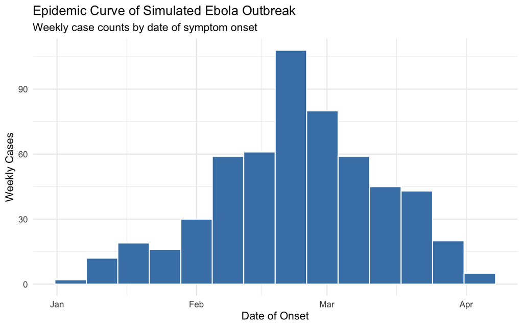

Epidemic curve showing weekly case counts. The peak indicates maximum transmission around day 40-50 of the outbreak.

```r
# Create visualizations
plots <- create_visualizations(tagged_linelist, cfr_results$rolling)

# Display epidemic curve
plots$epicurve
```

**Interpretation**:

- Peak occurred around day 40-50 of the outbreak
- The shape suggests exponential growth followed by decline
- Weekly binning smooths daily fluctuations

### Rolling CFR Estimates

The rolling CFR plot shows how our estimate of severity changes over time as more data accumulates.

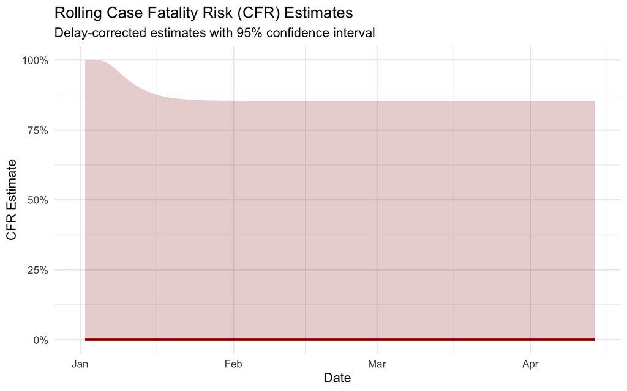

```r
# Display CFR plot
plots$cfr
```

### Summary Statistics

```r
# Create summary table
summary_stats <- tibble(
  Metric = c(
    "Total Cases",
    "Total Deaths",
    "Total Recovered",
    "Naive CFR",
    "Corrected CFR",
    "Mean Age (years)",
    "Outbreak Duration (days)"
  ),
  Value = c(
    nrow(tagged_linelist),
    sum(tagged_linelist$outcome == "died", na.rm = TRUE),
    sum(tagged_linelist$outcome == "recovered", na.rm = TRUE),
    paste0(round(naive_cfr * 100, 1), "%"),
    paste0(
      round(cfr_results$static$severity_estimate * 100, 1), "% ",
      "(", round(cfr_results$static$severity_low * 100, 1), "-",
      round(cfr_results$static$severity_high * 100, 1), "%)"
    ),
    round(mean(tagged_linelist$age, na.rm = TRUE), 1),
    as.numeric(
      difftime(
        max(tagged_linelist$date_onset),
        min(tagged_linelist$date_onset),
        units = "days"
      )
    )
  )
)

summary_stats |>
  gt() |>
  tab_header(title = "Outbreak Summary Statistics") |>
  cols_label(Metric = "Metric", Value = "Value")
```

Outbreak Summary Statistics

| Metric | Value |
| --- | --- |
| Total Cases | 559 |
| Total Deaths | 85 |
| Total Recovered | 474 |
| Naive CFR | 0% |
| Corrected CFR | 0% (0-85.4%) |
| Mean Age (years) | 44.5 |
| Outbreak Duration (days) | 91.8297330726849 |

## Data Preservation

### Save Processed Data

All data and outputs are saved for reproducibility and further analysis.

```r
# Save raw data
qs::qsave(
  outbreak$linelist,
  here::here("data", "raw", "simulated_linelist.qs")
)
qs::qsave(
  outbreak$contacts,
  here::here("data", "raw", "simulated_contacts.qs")
)

# Save processed data
qs::qsave(
  tagged_linelist,
  here::here("data", "processed", "cleaned_tagged_linelist.qs")
)

# Save CFR estimates
readr::write_csv(
  cfr_results$rolling,
  here::here("outputs", "tables", "cfr_rolling_estimates.csv")
)

# Save plots
ggplot2::ggsave(
  here::here("outputs", "plots", "epicurve.png"),
  plot = plots$epicurve,
  width = 8, height = 5, dpi = 300, bg = "white"
)

ggplot2::ggsave(
  here::here("outputs", "plots", "cfr_rolling.png"),
  plot = plots$cfr,
  width = 8, height = 5, dpi = 300, bg = "white"
)

cat("✓ All outputs saved to data/ and outputs/ directories\n")
```

```
✓ All outputs saved to data/ and outputs/ directories
```

## Discussion

### Methodological Considerations

**Strengths**:

**Limitations**:

- Simulated data may not capture all real-world complexities
- Homogeneous mixing assumption (no spatial structure)
- Constant transmission probability over time
- No healthcare capacity constraints modeled

### Applications

This workflow can be adapted for:

- **Training**: Teaching outbreak analysis methods
- **Planning**: Evaluating surveillance and response strategies
- **Testing**: Validating new analytical methods
- **Real outbreaks**: Replace simulation with actual data

### Package Versions

```r
# Display key package versions
key_packages <- c("simulist", "cleanepi", "linelist", "cfr", "epiparameter")

pkg_versions <- sapply(key_packages, function(pkg) {
  as.character(packageVersion(pkg))
})

tibble(
  Package = key_packages,
  Version = pkg_versions
) |>
  gt() |>
  tab_header(title = "Epiverse-TRACE Package Versions")
```

Epiverse-TRACE Package Versions

| Package | Version |
| --- | --- |
| simulist | 0.6.0 |
| cleanepi | 1.1.2.9000 |
| linelist | 2.0.1.9000 |
| cfr | 0.2.0.9000 |
| epiparameter | 0.4.1 |

## Reproducibility

This analysis is fully reproducible. To regenerate:

```bash
# From repository root
quarto render examples/ebola_outbreak/ebola_analysis.qmd
```

**Random Seed**: 42 (set in setup chunk)

**Data Provenance**: All data simulated using `simulist` package with documented parameters

**Analysis completed**: 2026-02-11 14:59:46 CET

**Repository**: epiagent_skills

**License**: MIT